# Кейс экзаменационный по методам количественным

*Введение* *Актуальность*

В образовательной политике нашей страны всё чаще фигурируют вопросы условий обучения в школах. В ряде государственных программ и проектов упоминается инфраструктура школ. Действующая политика, направленная на развитие образовательной инфраструктуры школ, зачастую носит инвариантный характер, и не всегда учитывает разнообразие сферы образования. При этом в России наблюдается дифференциация регионов по уровню обеспеченности ресурсами и экономическому положению в целом. Стоит учитывать, что возможности регионов разнятся в вопросах обеспечения сферы образования. Необходимо выяснить, как связаны основные показатели экономического развития региона с уровнем обеспеченности школ элементами образовательной инфраструктуры, и на какие характеристики региона следует опираться, при формировании образовательной политики в вопросах формирования образовательной инфраструктуры школ.

*Гипотеза*

Материально-техническое обеспечение школ связано с экономическим положением региона.

```r
library(haven)
library(readxl)
library(dplyr)
library(NbClust)
library(ggplot2)
library(factoextra)
library(skimr)
```

*Описание датасета*

Исследование будет проводиться на основе данных официальной статистики Росстата. Данные об уровне обеспеченности школ формируются из форм федерального статистического наблюдения ОО-1 и ОО-2 наиболее актуальных версий (за 2019 и 2018 год соответственно).

Данные по основным показателям экономического развития формируются из статистического сборника “Регионы России”. Для оценки связи уровня экономического развития и обеспеченности школ элементами образовательной инфраструктуры были отобраны следующие показатели:

1)ВРП на душу населения, 2)Отношение среднедушевых денежных доходов к стоимости фиксированного набора потребительских товаров и услуг 3)Индекс Джини 4)Инвестиции в основной капитал 5)Сальдированный финансовый результат (прибыль минус убыток) деятельности организаций

В качестве показателей обеспеченности школ элементами образовательной инфраструктуры были выбраны следующие:

1)Доля зданий, обеспеченных всеми формами благоустройства (Оборудованы водопроводом, водоотведением (канализацией), центральным отоплением) 2)Доля оборудованных кабинетов (ОИВТ, химия, физика и др.) в общем числе классных комнат 3)Число автотранспортных средств, предназначенных для перевозки обучающихся, на сотню учеников 4)Отношение суммарного количества персональных компьютеров, имеющих доступ к интернету, мультимедийных проекторов, интерактивных досок, принтеров, сканеров, МФУ к численности школ в регионе 5)Доля школ с максимальной скоростью интернета выше 2 Мбит/сек в числе школ, подключенных к сети интернет

```r
Case <- read_excel("Case.xlsx")

head(Case)
```

```
## # A tibble: 6 x 11
##   Sub     GRP_pc Sal_g   Gin Invest Saldo_fin   Fac Class   Bus  Tech   Int
##   <chr>    <dbl> <dbl> <dbl>  <dbl>     <dbl> <dbl> <dbl> <dbl> <dbl> <dbl>
## 1 Алтайс~ 2.16e5  2.18 0.378 109925     32799 0.945 0.230 0.208  57.8 0.650
## 2 Амурск~ 3.33e5  1.94 0.399 239705     10131 0.927 0.292 0.252  71.2 0.454
## 3 Арханг~ 6.41e5  1.91 0.382 191318     31702 0.781 0.232 0.210  75.1 0.672
## 4 Астрах~ 4.13e5  1.69 0.364 106674    127293 0.906 0.231 0.176  78.6 0.823
## 5 Белгор~ 5.06e5  2.23 0.393 134161    206103 0.974 0.312 0.336  77.1 0.976
## 6 Брянск~ 2.53e5  1.83 0.377  59719      8552 0.870 0.302 0.221  37.2 0.365
```

*Про методологию и цель кластеризации*

В качестве наглядной оценки дифференциации регионов по уровню экономического развития будет проведен кластерный анализ. Будет проведен иерархический кластерный анализ, так как этот метод применим, если нет первоначальной гипотезы о количестве кластеров, что позволяет проанализировать регионы по ряду показателей и установить оптимальное количество кластеров.

Методология кластеризации регионов по отобранным показателям включает: 1)стандартизацию исходных значений показателей; 2)кластеризация регионов по выбранным показателям с использованием языка R; 3)выбор оптимального варианта кластеризации по показателям внутригрупповых и межгрупповых расстояний между наблюдениями.

Для проверки связи будет использована линейная регрессия, где предикторами будут выступать переменные, характеризующие уровень экономического развития региона, а зависимой переменной будут по очереди выступать показатели обеспеченности школ инфраструктурой.

На основе линейной регрессии можно будет сделать вывод о наличии и характере связи между показателя экономического развития региона и обеспеченностью школ данного региона образовательной инфраструктурой. При наличии связи этих показателей можно будет сделать вывод о возможностях регионов разных кластеров обеспечить школы инфраструктурой.

```r
cor.test(Case$GRP_pc, Case$Sal_g)
```

```
##
##  Pearson's product-moment correlation
##
## data:  Case$GRP_pc and Case$Sal_g
## t = 9.5155, df = 83, p-value = 6.082e-15
## alternative hypothesis: true correlation is not equal to 0
## 95 percent confidence interval:
##  0.6018365 0.8106443
## sample estimates:
##       cor
## 0.7223126
```

```r
cor.test(Case$GRP_pc, Case$Gin)
```

```
##
##  Pearson's product-moment correlation
##
## data:  Case$GRP_pc and Case$Gin
## t = 1.0978, df = 83, p-value = 0.2755
## alternative hypothesis: true correlation is not equal to 0
## 95 percent confidence interval:
##  -0.09593402  0.32448666
## sample estimates:
##       cor
## 0.1196361
```

```r
cor.test(Case$GRP_pc, Case$Invest)
```

```
##
##  Pearson's product-moment correlation
##
## data:  Case$GRP_pc and Case$Invest
## t = 1.505, df = 83, p-value = 0.1361
## alternative hypothesis: true correlation is not equal to 0
## 95 percent confidence interval:
##  -0.05193789  0.36348791
## sample estimates:
##       cor
## 0.1629904
```

```r
cor.test(Case$GRP_pc, Case$Saldo_fin)
```

```
##
##  Pearson's product-moment correlation
##
## data:  Case$GRP_pc and Case$Saldo_fin
## t = 0.90275, df = 83, p-value = 0.3693
## alternative hypothesis: true correlation is not equal to 0
## 95 percent confidence interval:
##  -0.1169752  0.3053149
## sample estimates:
##        cor
## 0.09860715
```

```r
cor.test(Case$Sal_g, Case$Gin)
```

```
##
##  Pearson's product-moment correlation
##
## data:  Case$Sal_g and Case$Gin
## t = 3.7831, df = 83, p-value = 0.0002914
## alternative hypothesis: true correlation is not equal to 0
## 95 percent confidence interval:
##  0.1855362 0.5515414
## sample estimates:
##      cor
## 0.383496
```

```r
cor.test(Case$Sal_g, Case$Invest)
```

```
##
##  Pearson's product-moment correlation
##
## data:  Case$Sal_g and Case$Invest
## t = 4.2077, df = 83, p-value = 6.493e-05
## alternative hypothesis: true correlation is not equal to 0
## 95 percent confidence interval:
##  0.2263984 0.5805379
## sample estimates:
##       cor
## 0.4192913
```

```r
cor.test(Case$Sal_g, Case$Saldo_fin)
```

```
##
##  Pearson's product-moment correlation
##
## data:  Case$Sal_g and Case$Saldo_fin
## t = 3.5825, df = 83, p-value = 0.0005727
## alternative hypothesis: true correlation is not equal to 0
## 95 percent confidence interval:
##  0.1657553 0.5371794
## sample estimates:
##       cor
## 0.3659516
```

```r
cor.test(Case$Gin, Case$Invest)
```

```
##
##  Pearson's product-moment correlation
##
## data:  Case$Gin and Case$Invest
## t = 6.0254, df = 83, p-value = 4.454e-08
## alternative hypothesis: true correlation is not equal to 0
## 95 percent confidence interval:
##  0.3836169 0.6843111
## sample estimates:
##     cor
## 0.55164
```

```r
cor.test(Case$Gin, Case$Saldo_fin)
```

```
##
##  Pearson's product-moment correlation
##
## data:  Case$Gin and Case$Saldo_fin
## t = 4.6851, df = 83, p-value = 1.082e-05
## alternative hypothesis: true correlation is not equal to 0
## 95 percent confidence interval:
##  0.2705782 0.6109096
## sample estimates:
##       cor
## 0.4573296
```

*Оценка корреляции между показателями*

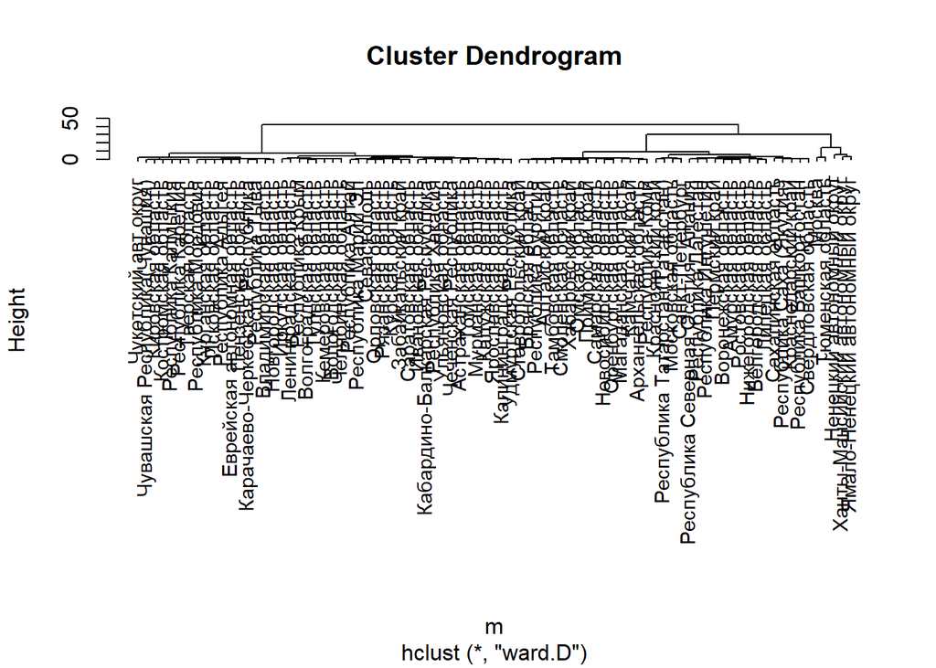

```r
to_clust <- Case %>% select ("GRP_pc", "Gin","Invest","Saldo_fin")
rownames(to_clust) <- Case$Sub
m <- dist(scale(to_clust))
hc <- hclust(m, method = "ward.D")

plot(hc, cex = 0.9)
```

*Оптимальное количество кластеров*

Для определения оптимального количества кластеров воспользуемся тремя подходами - метод каменистой осыпи (метод локтя), Силуэт-метод, пакет NbClust, который проводит оценку модели на основе 30 индексов качества и возвращает несколько вариантов деления на кластеры, в том числе называет оптимальное количество.

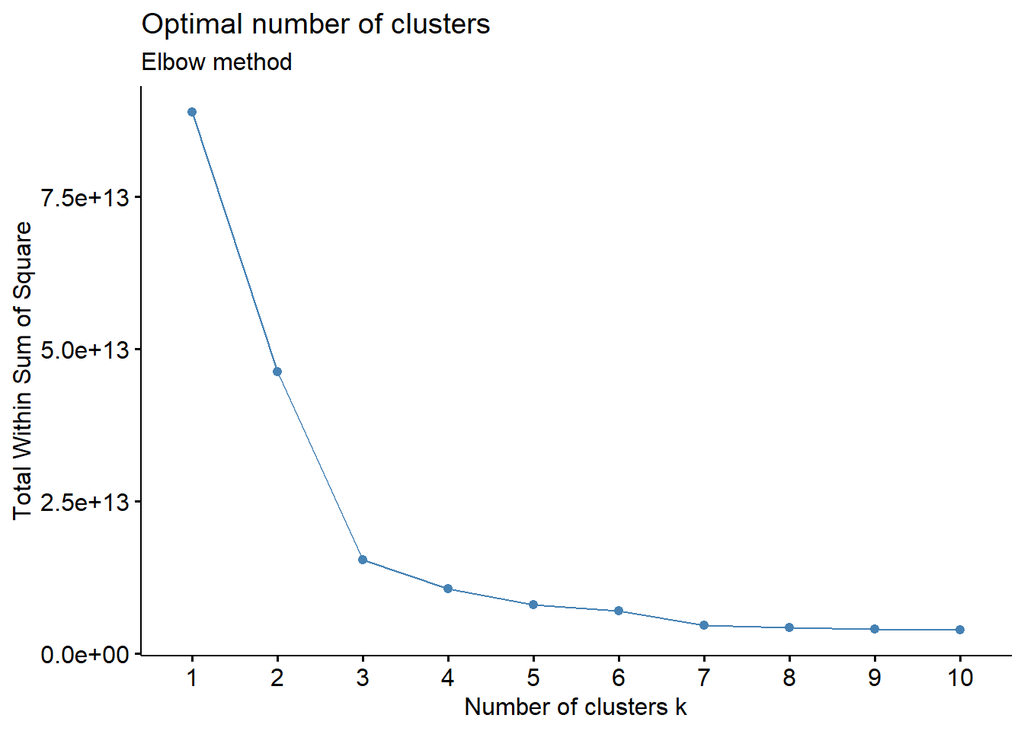

```r
fviz_nbclust(to_clust, kmeans, method = "wss") +
  labs(subtitle = "Elbow method")
```

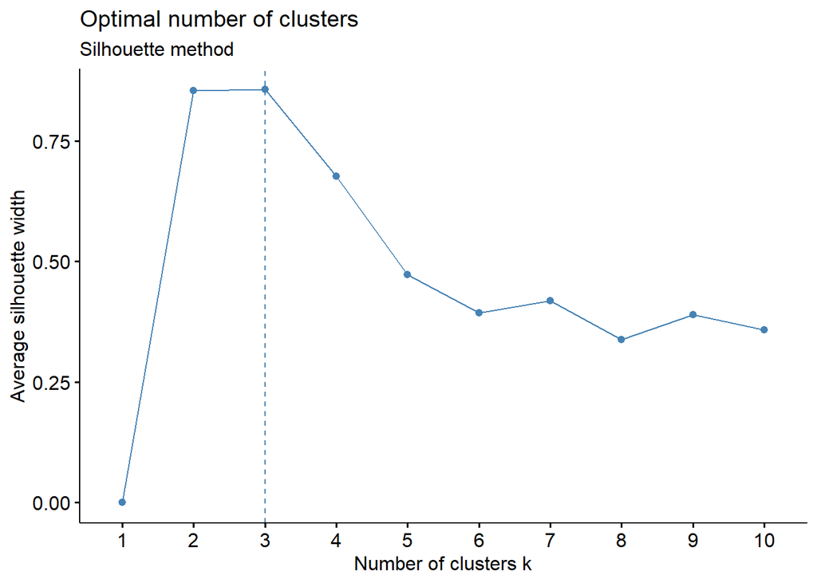

```r
fviz_nbclust(to_clust, kmeans, method = "silhouette") +
  labs(subtitle = "Silhouette method")
```

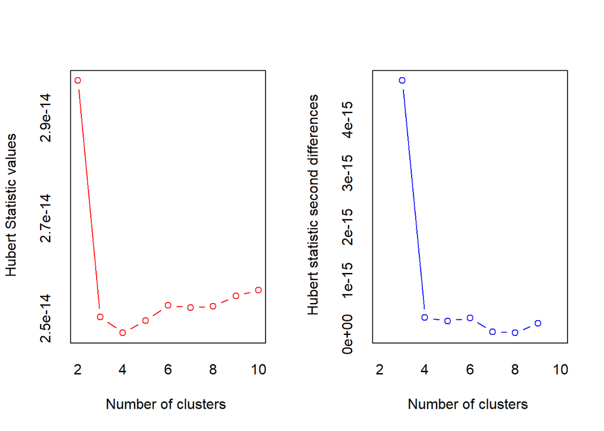

```
## *** : The Hubert index is a graphical method of determining the number of clusters.
##                 In the plot of Hubert index, we seek a significant knee that corresponds to a
##                 significant increase of the value of the measure i.e the significant peak in Hubert
##                 index second differences plot.
##
```

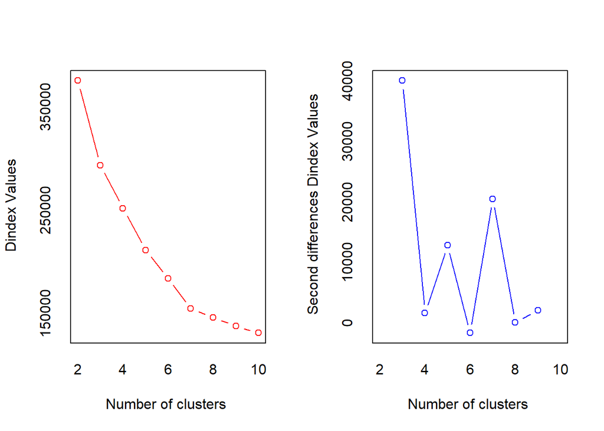

```
## *** : The D index is a graphical method of determining the number of clusters.
##                 In the plot of D index, we seek a significant knee (the significant peak in Dindex
##                 second differences plot) that corresponds to a significant increase of the value of
##                 the measure.
##
## * Among all indices:
## * 2 proposed 2 as the best number of clusters
## * 15 proposed 3 as the best number of clusters
## * 1 proposed 4 as the best number of clusters
## * 4 proposed 7 as the best number of clusters
## * 1 proposed 9 as the best number of clusters
##
##                    ***** Conclusion *****
##
## * According to the majority rule, the best number of clusters is  3
##
##
```

```r
res <- NbClust(to_clust, min.nc = 2, max.nc = 10, method = "kmeans")
```

*Оптимально - 3 кластера*

Согласно визуальныму анализу и результатам проверки модели с помощью пакета NbClust было установлено, что оптимальным количеством является 3 кластера. Визуализация этих кластеров представлена ниже.

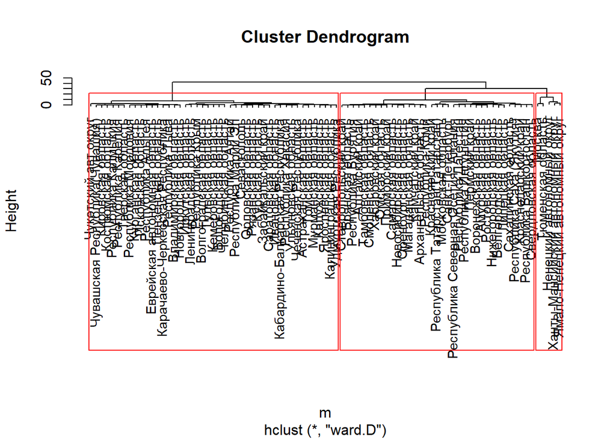

```r
plot(hc, cex = 0.9)
rect.hclust(hc, k = 3)
```

*Присвоим номера кластеров регионам*

```r
groups3 <- cutree(hc, k = 3)
Case$groups3 <- factor(groups3)
Case$Sub [Case$groups3 =="1"]
```

```
##  [1] "Алтайский край"
##  [2] "Амурская область"
##  [3] "Архангельская область"
##  [4] "Белгородская область"
##  [5] "Брянская область"
##  [6] "Воронежская область"
##  [7] "Камчатский край"
##  [8] "Краснодарский край"
##  [9] "Красноярский край"
## [10] "Липецкая область"
## [11] "Магаданская область"
## [12] "Московская область"
## [13] "Нижегородская область"
## [14] "Новосибирская область"
## [15] "Омская область"
```

[output cut: 20 more lines]

```r
Case$Sub [Case$groups3 =="2"]
```

```
##  [1] "Астраханская область"            "Владимирская область"
##  [3] "Волгоградская область"           "Вологодская область"
##  [5] "Еврейская автономная область"    "Забайкальский край"
##  [7] "Ивановская область"              "Иркутская область"
##  [9] "Кабардино-Балкарская Республика" "Калининградская область"
## [11] "Калужская область"               "Карачаево-Черкесская Республика"
## [13] "Кемеровская область"             "Кировская область"
## [15] "Костромская область"             "Курганская область"
## [17] "Курская область"                 "Ленинградская область"
## [19] "Мурманская область"              "Новгородская область"
## [21] "Орловская область"               "Пензенская область"
## [23] "Псковская область"               "Республика Адыгея"
## [25] "Республика Алтай"                "Республика Калмыкия"
## [27] "Республика Карелия"              "Республика Крым"
## [29] "Республика Марий Эл"             "Республика Мордовия"
## [31] "Республика Тыва"                 "Республика Хакасия"
## [33] "Рязанская область"               "Саратовская область"
## [35] "Севастополь"                     "Тверская область"
## [37] "Томская область"                 "Тульская область"
## [39] "Удмуртская Республика"           "Ульяновская область"
## [41] "Челябинская область"             "Чеченская Республика"
## [43] "Чувашская Республика(Чувашия)"   "Чукотский авт.округ"
## [45] "Ярославская область"
```

```r
Case$Sub [Case$groups3 =="3"]
```

```
## [1] "Москва"                            "Ненецкий автономный округ"
## [3] "Тюменская область"                 "Ханты-Мансийский автономный округ"
## [5] "Ямало-Ненецкий автономный округ"
```

*Характеристика кластеров*

Заметно, что наиболее сильные регионы в плане обеспеченности экономики нахоятся в 3 кластере. Чуть слабее регионы первого кластера - это середняки, а регионы второго кластера - наименее благополучные. Теперь посмотрим на разброс по показателям по каждому кластеру.

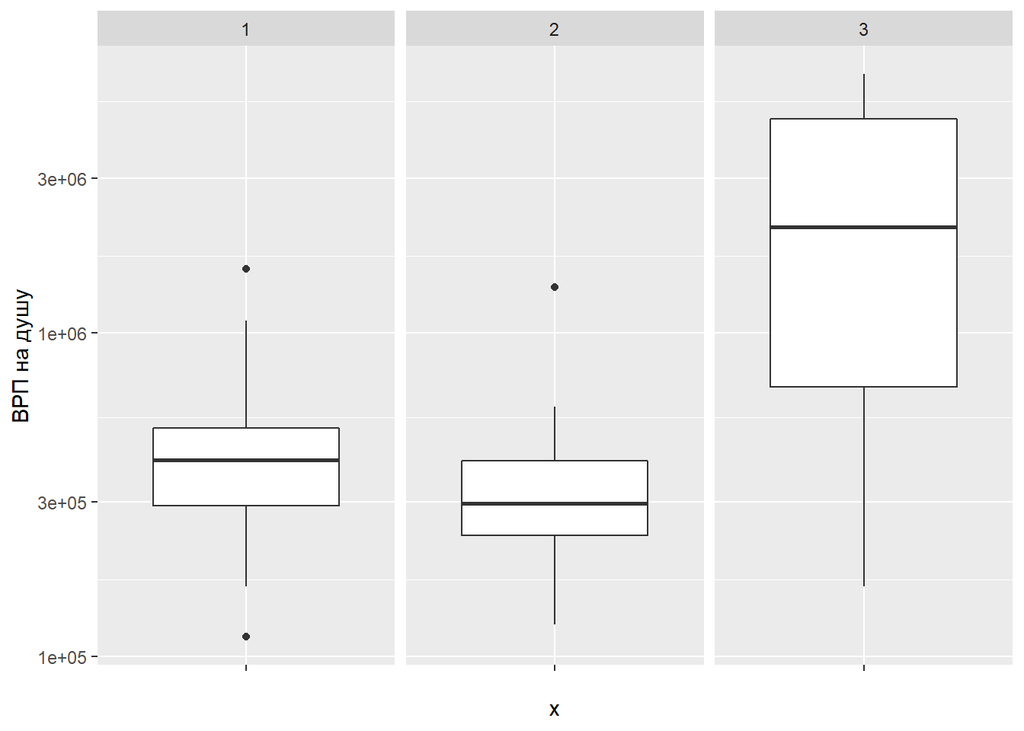

```r
ggplot(data = Case, aes(x = "", y = `GRP_pc`)) +
  geom_boxplot()+
  ylab ("ВРП на душу")+
  facet_grid(~groups3)+
  scale_y_log10()
```

*Интерпретация*

Построение боксплота позволяет оценить распределение значений, в данном случае это показатель ВРП на душу населения. Первый кластер имеет статистические выбросы, так как внутри кластера встречаются достаточно сильные регионы, не попавшие в третий кластер. Во втором кластере наименьший межквартильный размах, это говорит нам о том, что распределение значений показателей более однородное. В третьем кластере значительная разница междуверхним квартилем (75% значений показателя) и нижним квартилем (25% значений показателя), что говорит о достаточно большом межквартильном размахе и неоднородности распредления значений показателя.

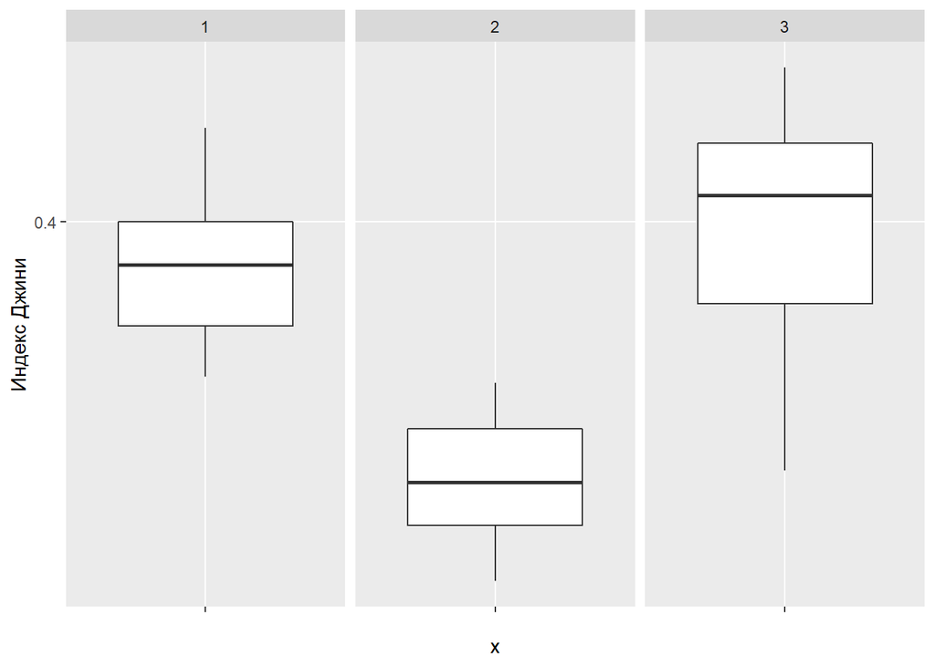

```r
ggplot(data = Case, aes(x = "", y = `Gin`)) +
  geom_boxplot()+
  ylab ("Индекс Джини")+
  facet_grid(~groups3)+
  scale_y_log10()
```

*Интерпретация*

Иерархия кластеров практически не меняется. С самым неоднородным распредлением также остаётся третий кластер, при этом он выше других, что говорит о наличии высокой дифференциации доходов внутри этих обеспеченных регионов. Первый кластер выше второго, что подтверждает факт наличия высокой дифференциации доходов населения при более высоком уровне экономичесокг оразвития региона.

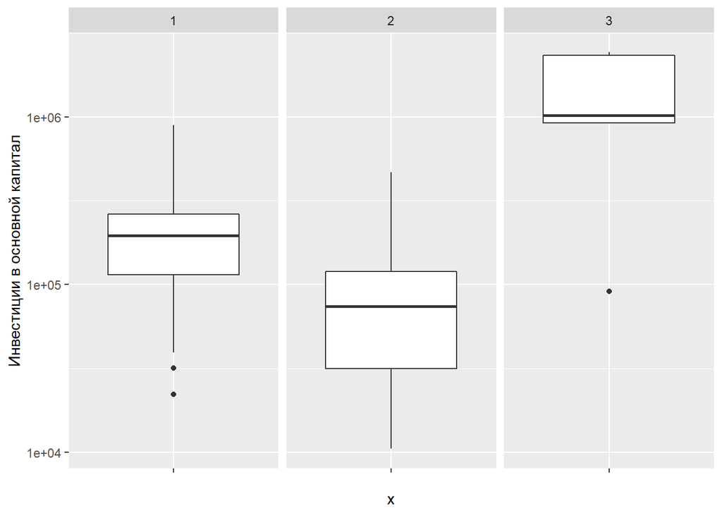

```r
ggplot(data = Case, aes(x = "", y = `Invest`)) +
  geom_boxplot()+
  ylab ("Инвестиции в основной капитал")+
  facet_grid(~groups3)+
  scale_y_log10()
```

*Интерпретация*

Прослеживается та же иерархия и разведение кластеров.

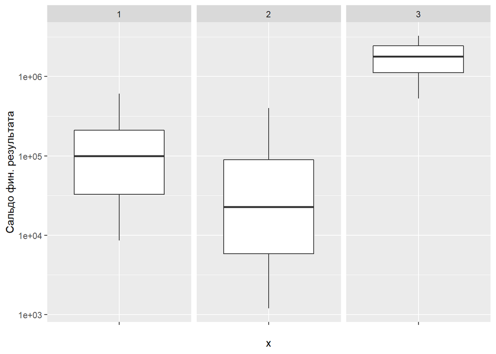

```r
ggplot(data = Case, aes(x = "", y = `Saldo_fin`)) +
  geom_boxplot()+
  ylab ("Сальдо фин. результата")+
  facet_grid(~groups3)+
  scale_y_log10()
```

*Интерпретация*

Видно, что третий кластер, как наиболее успешный в экономическом развитии находится значительно выше по финансовым результатам, а первый закономерно обгоняет второй.

*интерпретация кластеризации - есть типы региональных ситуаций*

Данная кластеризация демонстрирует возможность типологизации регионов по уровню экономического благополучия, что позволяет говорить о наличии как минимум 3 групп регионов.

*Посмотрим, как экономическое состояние региона связано с обеспеченностью школ основными формами благоустройства*

Проведем линейную регрессию, где зависимой переменной будет показатель, характеризующий обеспеченность школ в регионах материально-технической базой.

```r
model1 <- lm(data = Case, Fac ~ GRP_pc+Gin+Invest+Saldo_fin)
summary(model1)
```

```
##
## Call:
## lm(formula = Fac ~ GRP_pc + Gin + Invest + Saldo_fin, data = Case)
##
## Residuals:
##      Min       1Q   Median       3Q      Max
## -0.36110 -0.02849  0.03980  0.06826  0.12747
##
## Coefficients:
##               Estimate Std. Error t value Pr(>|t|)
## (Intercept)  8.912e-01  2.398e-01   3.717 0.000373 ***
## GRP_pc      -2.511e-08  1.479e-08  -1.697 0.093495 .
## Gin          4.498e-02  6.602e-01   0.068 0.945845
## Invest       3.128e-08  1.044e-07   0.300 0.765275
## Saldo_fin    2.523e-08  8.385e-08   0.301 0.764285
## ---
## Signif. codes:  0 '***' 0.001 '**' 0.01 '*' 0.05 '.' 0.1 ' ' 1
##
## Residual standard error: 0.1101 on 80 degrees of freedom
## Multiple R-squared:  0.07067,    Adjusted R-squared:  0.0242
## F-statistic: 1.521 on 4 and 80 DF,  p-value: 0.204
```

Эта модель несущественна, так как объясняет малую долю дисперсии.

```r
model2 <- lm(data = Case, Class ~ GRP_pc+Gin+Invest+Saldo_fin)
summary(model2)
```

```
##
## Call:
## lm(formula = Class ~ GRP_pc + Gin + Invest + Saldo_fin, data = Case)
##
## Residuals:
##       Min        1Q    Median        3Q       Max
## -0.155376 -0.018416 -0.001849  0.019952  0.098363
##
## Coefficients:
##               Estimate Std. Error t value Pr(>|t|)
## (Intercept)  2.572e-01  7.860e-02   3.272  0.00158 **
## GRP_pc       5.847e-09  4.849e-09   1.206  0.23148
## Gin         -1.574e-02  2.164e-01  -0.073  0.94220
## Invest      -1.759e-08  3.423e-08  -0.514  0.60866
## Saldo_fin   -3.728e-08  2.749e-08  -1.356  0.17878
## ---
## Signif. codes:  0 '***' 0.001 '**' 0.01 '*' 0.05 '.' 0.1 ' ' 1
##
## Residual standard error: 0.03608 on 80 degrees of freedom
## Multiple R-squared:  0.3117, Adjusted R-squared:  0.2773
## F-statistic: 9.059 on 4 and 80 DF,  p-value: 4.359e-06
```

Данная модель уже статистически значима, объясняет почти 28% дисперсии показателя по оборудованности классов.

```r
model3 <- lm(data = Case, Bus ~ GRP_pc+Gin+Invest+Saldo_fin)
summary(model3)
```

```
##
## Call:
## lm(formula = Bus ~ GRP_pc + Gin + Invest + Saldo_fin, data = Case)
##
## Residuals:
##       Min        1Q    Median        3Q       Max
## -0.165194 -0.040201  0.000657  0.036646  0.224717
##
## Coefficients:
##               Estimate Std. Error t value Pr(>|t|)
## (Intercept)  1.566e-01  1.822e-01   0.860   0.3926
## GRP_pc      -2.419e-08  1.124e-08  -2.152   0.0344 *
## Gin          1.439e-01  5.017e-01   0.287   0.7750
## Invest      -6.528e-10  7.935e-08  -0.008   0.9935
## Saldo_fin   -3.863e-08  6.372e-08  -0.606   0.5461
## ---
## Signif. codes:  0 '***' 0.001 '**' 0.01 '*' 0.05 '.' 0.1 ' ' 1
##
## Residual standard error: 0.08363 on 80 degrees of freedom
## Multiple R-squared:  0.09995,    Adjusted R-squared:  0.05495
## F-statistic: 2.221 on 4 and 80 DF,  p-value: 0.07404
```

Модель также незначима, её можно отвергнуть.

```r
model4 <- lm(data = Case, Tech ~ GRP_pc+Gin+Invest+Saldo_fin)
summary(model4)
```

```
##
## Call:
## lm(formula = Tech ~ GRP_pc + Gin + Invest + Saldo_fin, data = Case)
##
## Residuals:
##      Min       1Q   Median       3Q      Max
## -231.397  -18.124   -4.549   12.692  224.742
##
## Coefficients:
##               Estimate Std. Error t value Pr(>|t|)
## (Intercept)  8.870e+01  1.096e+02   0.809 0.420906
## GRP_pc       2.427e-05  6.764e-06   3.589 0.000571 ***
## Gin         -1.054e+02  3.018e+02  -0.349 0.727802
## Invest       4.174e-05  4.774e-05   0.874 0.384589
## Saldo_fin    7.995e-05  3.834e-05   2.085 0.040220 *
## ---
## Signif. codes:  0 '***' 0.001 '**' 0.01 '*' 0.05 '.' 0.1 ' ' 1
##
## Residual standard error: 50.32 on 80 degrees of freedom
## Multiple R-squared:  0.5745, Adjusted R-squared:  0.5532
## F-statistic:    27 on 4 and 80 DF,  p-value: 3.434e-14
```

Данная модель значима, она объясняет 55% дисперсии показателя обеспеченности компьютерной и периферийной техники. Чем выше ВРП региона - тем больше школы обеспечены техникой.

*Как экономическое состояние региона связано с обеспеченностью школ быстрым интернетом?*

```r
model5 <- lm(data = Case, Int ~ GRP_pc+Gin+Invest+Saldo_fin)
summary(model5)
```

```
##
## Call:
## lm(formula = Int ~ GRP_pc + Gin + Invest + Saldo_fin, data = Case)
##
## Residuals:
##      Min       1Q   Median       3Q      Max
## -0.48058 -0.11746  0.01422  0.14251  0.36010
##
## Coefficients:
##               Estimate Std. Error t value Pr(>|t|)
## (Intercept)  7.994e-01  4.180e-01   1.912   0.0594 .
## GRP_pc      -2.941e-08  2.579e-08  -1.140   0.2575
## Gin         -4.944e-01  1.151e+00  -0.430   0.6687
## Invest       2.609e-07  1.820e-07   1.433   0.1557
## Saldo_fin   -4.301e-08  1.462e-07  -0.294   0.7693
## ---
## Signif. codes:  0 '***' 0.001 '**' 0.01 '*' 0.05 '.' 0.1 ' ' 1
##
## Residual standard error: 0.1919 on 80 degrees of freedom
## Multiple R-squared:  0.1477, Adjusted R-squared:  0.1051
## F-statistic: 3.466 on 4 and 80 DF,  p-value: 0.01156
```

Данная модель также значима, она объясняет 10% дисперсии обеспеченности школ быстрым интернетом.

*Вывод*

Можно сделать вывод, что обеспеченность школ быстрым интернетом, компьютерной и периферийной техникой, и оборудованность классов связаны с показателями экономического благополучия региона. Так как была обоснована возможность разделить регионы по уровню экономического развития, то есть создать типологию регионов, то можно говорить и о характерных управленческих решениях для каждой группы регионов. Было установлено, что экономическое развитие связано с обеспеченностью школ некоторыми элементами инфраструктуры, значит относительно кластеров, опираясь на уроень экономического развития регионов, должна создаваться закономерная политика по формированию инфраструктуры школ, с расчетом на возможности регионов.